# Forecasting Inflation

Michael Rivera

2022-04-10

```r
require(fpp3)
require(tsibble)
require(tidyverse)
require(tidyquant)
require(lubridate)
require(timetk)
require(kableExtra)
require(dplyr)
require(reshape2)
require(ggplot2)
```

# Abstract

The focus of this article is the Phillips curve regarding its development and the array of models derived from such. The Phillips curve is known as the supposed inverse relationship between the level of unemployment and the rate of inflation. It has played a vital role in the decision-making process pertaining to macroeconomic policy. There was focus on other variables to see if another variable was capable of better representing this relationship; individually and collectively. The concluding data has determined INDPRO, the variable which represents Industrial Production through a total index while being seasonally adjusted to be the one which makes the strongest case to predict the rate of inflation. Taking all things considered, all of the models performed poorly in predicting inflation.

# Introduction

Inflation has become something not only do economists look at and monitor, but also the general public. Further insight into inflation and the continuation of understanding its impact on the economy is boundless. To progress towards growing comprehension, we must find indicators that are capable of effectively representing the relationship. These indicators will take place of unemployment and determine whether they are accurately forecasting the future inflation rates.

# Data Usage

As aforementioned, new indicators will be taking place of unemployment to see how the relationship with inflation is represented. Ideally, the search is for one that better predicts future inflation rates.

**PCEPI**

- Personal Consumption Expenditures: Chain-type Price Index - a measure of the prices that people living in the United States pay for goods and services; used for obtaining the inflation rate.

**UNRATE**

- Unemployment Rate - number of unemployed as a percentage of the labor force; used for creating the Philips curve specification.

**INDPRO**

- This index is presented with 2017 data regarding Industrial Production regarding to a total index with seasonally adjusted values.
- INDPRO is an economic indicator that measures real output for all facilities located in the United States manufacturing, mining, and electric, and gas utilities.

**MICH**

- University of Michigan: Inflation Expectation - a survey of consumers of the median expected price change next in the next 12 months done by the University of Michigan.

**HOUST**

- New Privately-Owned Housing Units Started: Total Units - new residential construction projects that begin during a certain month.

# Model Specifications

Using monthly data, the Stock & Watson (1999) specification of the Phillips curve is:

$$\pi^{12}_t - \pi_{t-12} = \phi +
\beta(B)\Delta \pi_{t-12} + \gamma(B) u_{t-12} + \varepsilon_t$$

```r
varList <- c("PCEPI", "UNRATE", "MICH", "INDPRO", "HOUST")
X <-
    tq_get(varList, get = "economic.data", from = "1982-01-01") %>%
    mutate(Month = yearmonth(date), value = price) %>%
    dplyr::select(-c(date, price)) %>%
    as_tsibble(index = Month, key = symbol)
Xw <- X %>%
    pivot_wider(names_from = symbol, values_from = value) %>%
    as_tsibble() %>%
    drop_na()
```

# Plots of Data

Firstly, the raw data for each variable is being plotted. This will allow us to identify if any variable needs to be manipulated to represent it accurately.

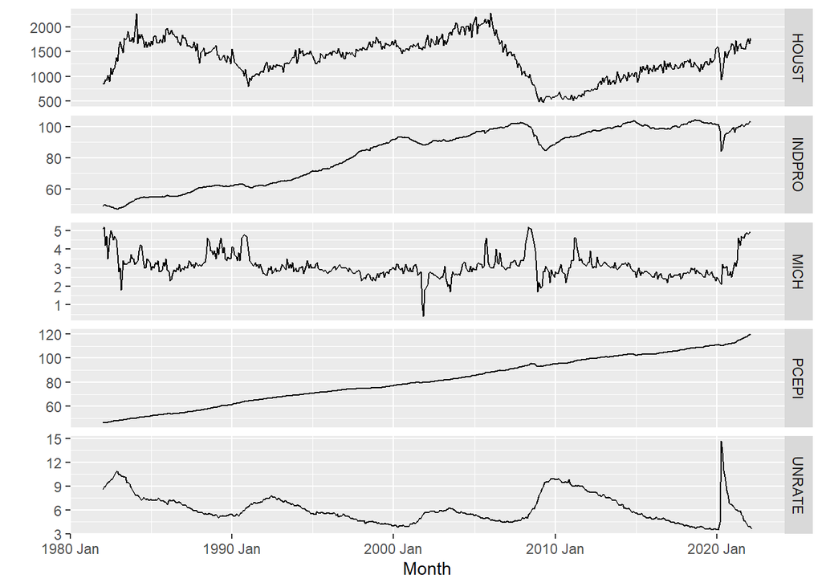

```r
X %>%
  ggplot(aes(x = Month, y = value)) +
  geom_line() +
  facet_grid(vars(symbol), scales = "free_y") +
  labs(y = " ")
```

As PCEPI, INDPRO and HOUST are level variables that likely grow exponentially, we must transform them and focus on the log of these variables to best model their representation.

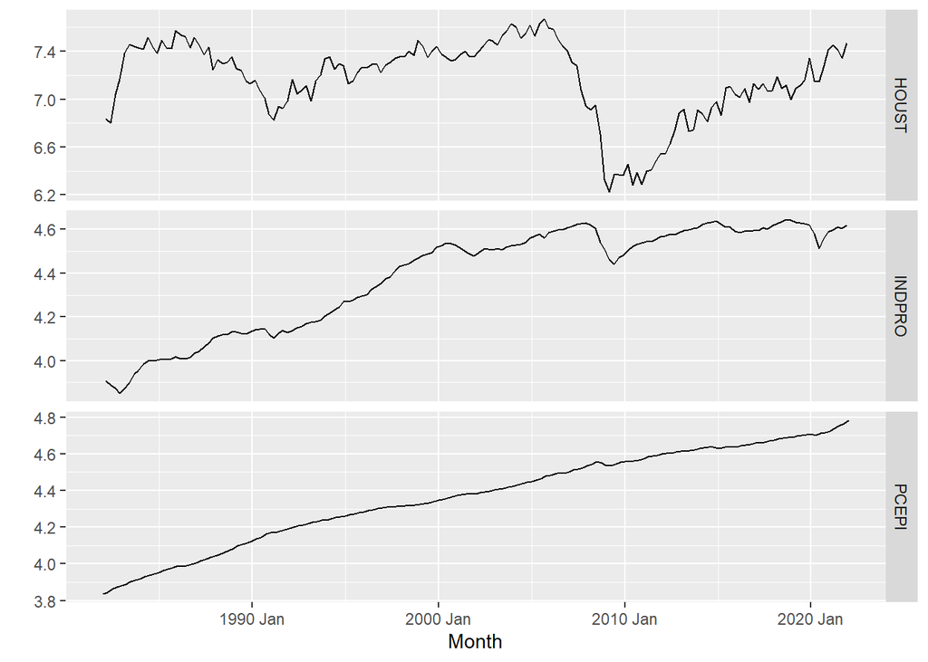

```r
X1 <- X %>% filter(symbol==c("PCEPI","INDPRO","HOUST"))
X1 %>%
  ggplot(aes(x = Month, y = log(value))) +
  geom_line() +
  facet_grid(vars(symbol), scales = "free_y") +
  labs(y = " ")
```

# Unit Root Testing

As these three variables appear to be non-stationary, we will proceed with a KPSS unit root test to confirm.

```r
X1 %>%
  features(log(value), unitroot_kpss) %>%
  kable(format = "html", table.attr = "style='width:30%;' ") %>%
  kableExtra::kable_styling()
```

| symbol | kpss_stat | kpss_pvalue |
| --- | --- | --- |
| HOUST | 0.619503 | 0.0208634 |
| INDPRO | 2.937151 | 0.0100000 |
| PCEPI | 3.253632 | 0.0100000 |

These variables will ideally contain only a single UR root.

```r
X1 %>%
  features(log(value), unitroot_ndiffs) %>%
  kable(format = "html", table.attr = "style='width:30%;' ") %>%
  kableExtra::kable_styling()
```

| symbol | ndiffs |
| --- | --- |
| HOUST | 1 |
| INDPRO | 1 |
| PCEPI | 2 |

```r
X %>% filter(symbol=="PCEPI") %>%
  features(value, unitroot_kpss) %>%
  kable(format = "html", table.attr = "style='width:30%;' ") %>%
  kableExtra::kable_styling()
```

| symbol | kpss_stat | kpss_pvalue |
| --- | --- | --- |
| PCEPI | 8.092291 | 0.01 |

We must difference the variable MICH to address it for not being seasonally adjusted. Once difference’d, this will allow the data to be stationary which means throughout the data in regards to time, the mean and variance will be constant.

```r
Xw <- Xw %>%
  mutate(dif_MICH = difference(MICH))

Xw %>% features(dif_MICH, unitroot_kpss)
```

| kpss_stat | kpss_pvalue |
| --- | --- |
| 0.1127213 | 0.1 |

```r
Z <- Xw %>% select(c(PCEPI, UNRATE, dif_MICH, INDPRO, HOUST)) %>%
  mutate(infl = 1200*log(PCEPI/lag(PCEPI))) %>%
  mutate(dinfl = infl - lag(infl,1)) %>%
  mutate(dinfl12 = 100*log(PCEPI/lag(PCEPI,12)) - lag(infl,12)) %>%
  mutate(unrate = UNRATE - lag(UNRATE)) %>%
  mutate(dif_mich = dif_MICH - lag(dif_MICH)) %>%
  mutate(indpro = 1200*log(INDPRO/lag(INDPRO))) %>%
  mutate(houst = 100*log(HOUST/lag(HOUST))) %>%
  select(-c(PCEPI, UNRATE, INDPRO, HOUST)) %>%
  drop_na()
train_data <- Z %>% filter_index(~ "2018-12")
test_data <- Z %>% filter_index("2019-01" ~ .)
```

```r
train <- Z %>% filter_index(~ "2018-12")
test <- Z %>% filter_index("2019-01" ~ .)
```

# Melting Data

The decision to melt the data is to customize and manipulate the data values from a wider format to one of which that implements restrictions. This allows optimization regarding any sort of identifier for the corresponding data attributes.This will include the difference’d outputs for the variable MICH.

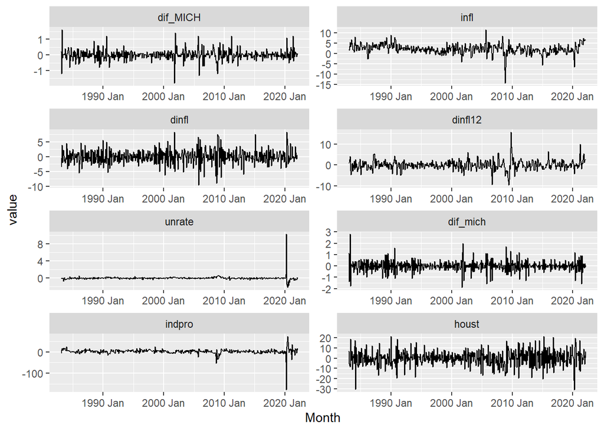

```r
Zm <- melt(Z, "Month")
ggplot(Zm, aes(Month, value)) +
  geom_line() +
  facet_wrap(~variable, scales = "free", ncol = 2)
```

```r
fitPC <- train_data %>%
  model(
    meltUNRATE = TSLM(dinfl12 ~ 1 +
                 lag(dinfl,12) + lag(dinfl,13) + lag(dinfl,14) +
                 lag(dinfl,15) + lag(dinfl,16) + lag(dinfl,17) +
                 lag(dinfl,18) + lag(dinfl,19) + lag(dinfl,20) +
                 lag(dinfl,21) + lag(dinfl,22) + lag(dinfl,23) +
                 lag(unrate,12) + lag(unrate,13) + lag(unrate,14) +
                 lag(unrate,15) + lag(unrate,16) + lag(unrate,17) +
                 lag(unrate,18) + lag(unrate,19) + lag(unrate,20) +
                 lag(unrate,21) + lag(unrate,22) + lag(unrate,23)),

    meltMICH = TSLM(dinfl12 ~ 1 +
                 lag(dinfl,12) + lag(dinfl,13) + lag(dinfl,14) +
                 lag(dinfl,15) + lag(dinfl,16) + lag(dinfl,17) +
                 lag(dinfl,18) + lag(dinfl,19) + lag(dinfl,20) +
                 lag(dinfl,21) + lag(dinfl,22) + lag(dinfl,23) +
                 lag(dif_MICH,12) + lag(dif_MICH,13) + lag(dif_MICH,14) +
                 lag(dif_MICH, 15) + lag(dif_MICH,16) + lag(dif_MICH,17) +
                 lag(dif_MICH,18) + lag(dif_MICH,19) + lag(dif_MICH,20) +
                 lag(dif_MICH,21) + lag(dif_MICH,22) + lag(dif_MICH,23)),

    meltINDPRO = TSLM(dinfl12 ~ 1 +
                 lag(dinfl,12) + lag(dinfl,13) + lag(dinfl,14) +
                 lag(dinfl,15) + lag(dinfl,16) + lag(dinfl,17) +
                 lag(dinfl,18) + lag(dinfl,19) + lag(dinfl,20) +
                 lag(dinfl,21) + lag(dinfl,22) + lag(dinfl,23) +
                 lag(indpro,12) + lag(indpro,13) + lag(indpro,14) +
                 lag(indpro, 15) + lag(indpro,16) + lag(indpro,17) +
                 lag(indpro,18) + lag(indpro,19) + lag(indpro,20) +
                 lag(indpro,21) + lag(indpro,22) + lag(indpro,23)),

    meltHOUST = TSLM(dinfl12 ~ 1 +
                 lag(dinfl,12) + lag(dinfl,13) + lag(dinfl,14) +
                 lag(dinfl,15) + lag(dinfl,16) + lag(dinfl,17) +
                 lag(dinfl,18) + lag(dinfl,19) + lag(dinfl,20) +
                 lag(dinfl,21) + lag(dinfl,22) + lag(dinfl,23) +
                 lag(houst,12) + lag(houst,13) + lag(houst,14) +
                 lag(houst, 15) + lag(houst,16) + lag(houst,17) +
                 lag(houst,18) + lag(houst,19) + lag(houst,20) +
                 lag(houst,21) + lag(houst,22) + lag(houst,23)),
    )
report(fitPC)
```

| .model | r_squared | adj_r_squared | sigma2 | statistic | p_value | df | log_lik | AIC | AICc | BIC | CV | deviance | df.residual | rank |
| --- | --- | --- | --- | --- | --- | --- | --- | --- | --- | --- | --- | --- | --- | --- |
| meltUNRATE | 0.7501624 | 0.7345068 | 1.360781 | 47.91649 | 8.629383e-100 | 25 | -628.8715 | 151.88924 | 155.57428 | 256.1822 | 1.499297 | 521.1791 | 383 | 25 |
| meltMICH | 0.8004538 | 0.7879495 | 1.086861 | 64.01477 | 3.554133e-118 | 25 | -583.0195 | 60.18507 | 63.87011 | 164.4780 | 1.168111 | 416.2677 | 383 | 25 |
| meltINDPRO | 0.7701286 | 0.7557241 | 1.252032 | 53.46454 | 1.359837e-106 | 25 | -611.8801 | 117.90644 | 121.59148 | 222.1994 | 1.382466 | 479.5281 | 383 | 25 |
| meltHOUST | 0.7392227 | 0.7228816 | 1.420366 | 45.23693 | 2.694534e-96 | 25 | -637.6141 | 169.37432 | 173.05936 | 273.6673 | 1.590927 | 544.0000 | 383 | 25 |

## Forecasting Results

We will now be including an ensemble model by averaging all previous models:

$$mEnsemble = (meltUNRATE + meltMICH +
meltINDPRO + meltHOUST)/4$$

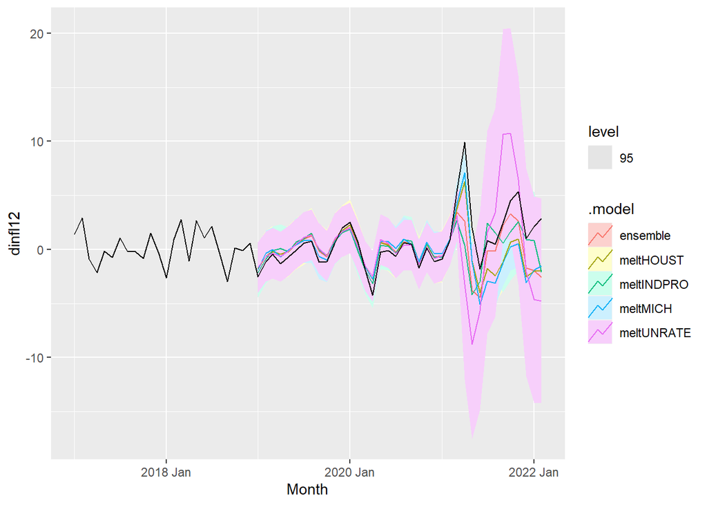

```r
fit_ensemble <- fitPC %>%
  mutate(ensemble = (meltUNRATE + meltMICH + meltINDPRO + meltHOUST)/4)
  fc_ensemble <- fit_ensemble %>% forecast(new_data = test_data)
  fc_ensemble %>% autoplot(filter(Z, year(Month) > 2016), level = c(95))
```

# Accuracy of Training Data

In-Sample Data:

The original melted variables in regard to training data set while comparing MAPE. This table includes the ensemble which represents the summary of all represented. The model is utilizing lagged inflation where the total index for Industry Production variable having the lowest MAPE.

```r
fit_ensemble1 <- accuracy(fit_ensemble) %>%
  select(c(".model", ".type", "MAPE")) %>%
  kable(format = "html", table.attr = "style='width:30;' " ) %>%
  kableExtra::kable_styling()
fit_ensemble1
```

| .model | .type | MAPE |
| --- | --- | --- |
| meltUNRATE | Training | 195.0650 |
| meltMICH | Training | 268.5676 |
| meltINDPRO | Training | 177.5236 |
| meltHOUST | Training | 204.6392 |
| ensemble | Training | 185.9997 |

# Accuracy of Test Data

Out-of-Sample Data:

The original melted variables in regard to training data set while comparing MAPE. This table includes the ensemble which represents the summary of all represented. The MAPE for ensemble is extremely close to the MAPE for meltINDPRO, but it does not outperform the overall summary variable. The model is utilizing lagged inflation where the total index for Industry Production variable having the lowest MAPE.

```r
fc_ensemble1 <- accuracy(fc_ensemble, Z) %>%
  select(c(".model", ".type", "MAPE")) %>%
  kable(format = "html", table.attr = "style='width:30;' ") %>%
  kableExtra::kable_styling()
fc_ensemble1
```

| .model | .type | MAPE |
| --- | --- | --- |
| ensemble | Test | 115.0562 |
| meltHOUST | Test | 131.2759 |
| meltINDPRO | Test | 112.3413 |
| meltMICH | Test | 152.7666 |
| meltUNRATE | Test | 154.6405 |

# Conclusion

The ending results of this analysis, the total index for Industry Production variable being melted with restrictions and the ensemble variable were the two best indicators for forecasting the future rates of inflation. The variable meltINDPRO outperformed all other variables we replaced unemployment for. Overall, none of the variables were exceptional in showcasing these predictions. Further testing and analysis must be done to truly find something that can perform effectively.